# Final Project

Rakel Faaland

2022-11-22

# Analysis of NYC Resources by Borough

## **INTRODUCTION**

### Research Question:

I am interested in exploring the following research question: **What resources are available to New Yorkers living in poverty or at risk of homelessness?**

In New York City, there are a lot of people experiencing homelessness, and the problem has only increased since the COVID-19 pandemic. According to predictions by the United States Census Bureau, 17% of New York City live in poverty. Solving the issue of poverty and homelessness is complex, and every individual has a unique set of needs that requires different services. In my analysis, I want to investigate what resources are available to serve those living in poverty and those at risk of, or experiencing, homelessness.

### Data Sources:

For this project, I use NYC Open Data as the source of all my data. NYC Open Data provides free data to the public from various New York City government agencies. The NYC Office of Technology and Innovation manages NYC Open Data. The datasets I will be using are detailed below.

- [“Directory Of Homebase Locations”](https://data.cityofnewyork.us/Social-Services/Directory-Of-Homebase-Locations/ntcm-2w4k)
  - The “Directory Of Homebase Locations” dataset is provided by the Department of Homeless Services (DHS). The DHS is a government organization that provides services to New Yorkers who are experiencing homelessness.
  - This dataset has 26 rows and 14 columns. Each observation is a homebase office. The variables in this dataset are the following: Provider, Service Area Zipcode, Address, Phone Number, Postcode, Borough, Latitude, Longitude, Community Board, Council District, Census Tract, BIN, BBL, NTA.
- [“Evictions”](https://data.cityofnewyork.us/City-Government/Evictions/6z8x-wfk4)
  - The “Evictions” dataset is provided by the Department of Investigation (DOI). The DOI is a government law enforcement agency that conducts covert investigations within the government and in organizations receiving benefits from the New York City government programs.
  - This dataset has 71.2K rows and 20 columns. Each observation is an eviction. The variables in this dataset are the following: Court Index Number, Docket Number, Eviction Address, Evictions Apartment Number, Executed Date, Marshal First Name, Marshal Last Name, Residential/Commercial, Borough, Eviction Postcode, Ejectment, Eviction/Legal Possession, Latitude, Longitude, Community Board, Council District, Census Tract, BIN, BBL, NTA.
- [“Buildings by Borough and Community District”](https://data.cityofnewyork.us/Social-Services/Buildings-by-Borough-and-Community-District/3qem-6v3v)
  - The “Buildings by Borough and Community District” dataset is provided by the Directory of Homeless Services (DHS). The DHS is a government organization that provides services to New Yorkers who are experiencing homelessness.
  - This dataset has 2,578 rows and 10 columns. Each observation is a shelter. The variables in this dataset are the following: Report Date, Borough, Community District, Adult Family Community Hotel, Adult Family Shelter, Adult Shelter, Adult Shelter Community Hotel, Families With Children Cluster, Families With Children Community Hotel, Families With Children Shelter.
- [“Borough/Community District Report - SNAP Population”](https://data.cityofnewyork.us/Social-Services/Borough-Community-District-Report-SNAP-Population/jye8-w4d7)
  - The “Borough/Community District Report - SNAP Population” dataset is provided by the Human Resources Administration (HRA). The HRA is a government organization that helps low-income New Yorkers with food assistance and emergency rental assistance.
  - This dataset has 1,003 rows and 5 columns. Each observation is a monthly report on a community district. The variables in this dataset are the following: Month, Borough, Community District Number, SNAP recipients, SNAP households.
- [“DYCD after-school programs: Jobs and Internships”](https://data.cityofnewyork.us/Education/DYCD-after-school-programs-Jobs-and-Internships/99br-frp6)
  - The “DYCD after-school programs: Jobs and Internships” dataset is provided by the Department of Youth and Community Development (DYCD). The DYCD is a government organization that supports youth and families in New York by funding community organizations.
  - This dataset has 208 rows and 18 columns. Each observation is a program. The variables in this dataset are the following: Program Type, Program, Site Name, Address, Borough, Postcode, Agency, Contact Number, Grade Level / Age Group, Location 1, Latitude, Longitude, Community Board, Community Council, Census Tract, BIN, BBL, NTA.
- [“Financial Empowerment Centers”](https://data.cityofnewyork.us/Business/Financial-Empowerment-Centers/dt2z-amuf)
  - The “Financial Empowerment Centers” dataset is provided by the Department of Consumer and Worker Protection (DCWP). The DCWP is a government organization that supports businesses and individuals regarding finance. They license businesses, provide business resources, advocate for wages, and provide community outreach like their Financial Empowerment Centers.
  - This dataset has 23 rows and 23 columns. Each observation is a center. The variables in this dataset are the following: Provider, Host Organization, Building, Street, City, Borough, Postcode, Site Location Address, Days Open, Hours, Language(s), Telephone, Council District, Community Board, BBL, NTA, X coordinates, Y coordinates, Latitude, Longitude, Census Tract, BIN, Location.
- [“Directory of NYCHA Community Facilities”](https://data.cityofnewyork.us/Social-Services/Directory-of-NYCHA-Community-Facilities/crns-fw6u)
  - The “Directory of NYCHA Community Facilities” dataset is provided by the New York City Housing Authority (NYCHA). NYCHA is a government organization that provides public housing to low-income New Yorkers. It also connects its recipients with opportunities related to career advancement, continuing education, and learning about financial health.
  - This dataset has 430 rows and 16 columns. Each observation is a NYCHA community facility. The variables in this dataset are the following: Type, Funding Agency, Borough, Program Type, Status, Development, Address, Sponsor, Latitude, Longitude, Community Board, Council District, Census Tract, BIN, BBL, NTA.
- [“Directory of SNAP Centers”](https://data.cityofnewyork.us/Social-Services/Directory-of-SNAP-Centers/tc6u-8rnp)
  - The “Directory of SNAP Centers” dataset is provided by the Human Resources Administration (HRA). The HRA is a government organization that helps low-income New Yorkers with food assistance and emergency rental assistance.
  - This dataset has 14 rows and 16 columns. Each observation is a SNAP center. The variables in this dataset are the following: Borough, Facility Name, Street Address, City, Postcode, State, Phone Number(s), Comments, Latitude, Longitude, Community Board, Council District, Census Tract, BIN, BBL, NTA.
- [“New York City Population by Borough, 1950 - 2040”](https://data.cityofnewyork.us/City-Government/New-York-City-Population-by-Borough-1950-2040/xywu-7bv9)
  - The “New York City Population by Borough, 1950 - 2040” dataset is provided by the Department of City Planning (DCP). The DCP is a government organization that oversees city land use for housing, neighborhood development, sustainability, and economic development.
  - This dataset has 6 rows and 22 columns. Each observation represents a total. The 6 rows contain the 5 boroughs and a row for New York City as a whole. The variables in this dataset are the following: Age Group, Borough, 1950, 1950 - Borough Share of NYC Total, 1960, 1960 - Borough Share of NYC Total, 1970, 1970 - Borough Share of NYC Total, 1980, 1980 - Borough Share of NYC Total, 1990, 1990 - Borough Share of NYC Total, 2000, 2000 - Borough Share of NYC Total, 2010, 2010 - Borough Share of NYC Total, 2020, 2020 - Borough Share of NYC Total, 2030, 2030 - Borough Share of NYC Total, 2040, 2040 - Borough Share of NYC Total.

### Method:

In order to investigate my research question, I will use the data sets I have selected above to create three new data frames. These data frames will contain counts and percentages by the borough of the New York City population, New York City resources, and New York City poverty indicators.

For the New York City population data frame, I will be using only the data from 2020. This data will give context to my later analysis of the distribution of resources and poverty indicators by depicting how New York City’s population is spread throughout the five boroughs.

The New York City resources data frame will contain the following variables: Homebase Offices, Shelters, Employment Programs, Financial Empowerment Centers, Community Centers, and SNAP Centers. This will show how these resources are distributed through the five boroughs of New York City.

The poverty indicators data frame will contain the following variables: Residential Evictions, and SNAP Recipients. These variables will be used to identify cases of people experiencing economic hardship and at risk of homelessness. It will help to identify where the greatest need for resources is in New York City’s five boroughs.

In my analysis, I will compare the distribution of resources, poverty indicators, and population within each borough to provide a picture of the need and resource allocation in New York City by borough.

## **OVERVIEW**

### How should New York City’s resources be distributed?

New York City’s population is not distributed evenly throughout the five boroughs. Figure 1 shows that Brooklyn and Queens have the highest percentage of the population - at 31% and 27%. The Bronx and Manhattan have roughly 10% less - at 17% and 19%. Staten Island has the least amount of people - at about 6%.

New York City should distribute resources based on the need of each borough. Therefore, the distribution of poverty indicators, rather than the population, is more important. Figure 2 demonstrates the distribution of evictions and SNAP recipients by borough. This graph shows that the Bronx and Brooklyn have between 28% and 35% of residential evictions and SNAP recipients in New York City. This is the highest percentage in all boroughs, indicating that residents of these two boroughs may have a higher need for resources. Manhattan and Queens have between 14% and 19% of residential evictions and SNAP recipients. Staten Island has the least of all with 4% of residential evictions and SNAP recipients.

### How is New York City distributing resources to help alleviate poverty?

Figure 4 depicts the distribution of resources aimed to help people experiencing poverty. These resources are defined in the legend as homebase offices, shelters, employment programs, financial empowerment centers, community centers, and SNAP centers.

- The homebase offices are locations where people who are at risk of experiencing homelessness can get resources such as temporary housing.
- Shelters are homeless shelters where people experiencing homelessness can live.
- Employment programs are programs for youth and adults.
- Financial empowerment centers are places where people can get training and advice to better manage their finances and get out of poverty.
- Community centers are places that are open to the public for recreation. These include senior centers, family centers, and more.
- SNAP centers are locations where people can receive benefits such as food assistance.

Figure 4 shows that Brooklyn, the Bronx, and Manhattan generally have a higher percentage of resources than Queens and Staten Island. However, this is not true for every benefit. (See Figure 5 for detailed plots on each resource.) Nonetheless, it does demonstrate that New York City is allocating resources well based on need because Figure 2 shows that Brooklyn and the Bronx have the highest need.

Figure 1

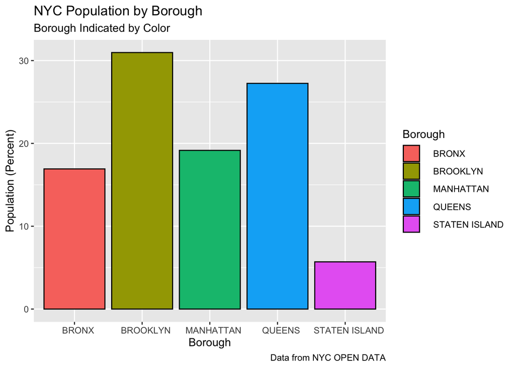

Figure 2

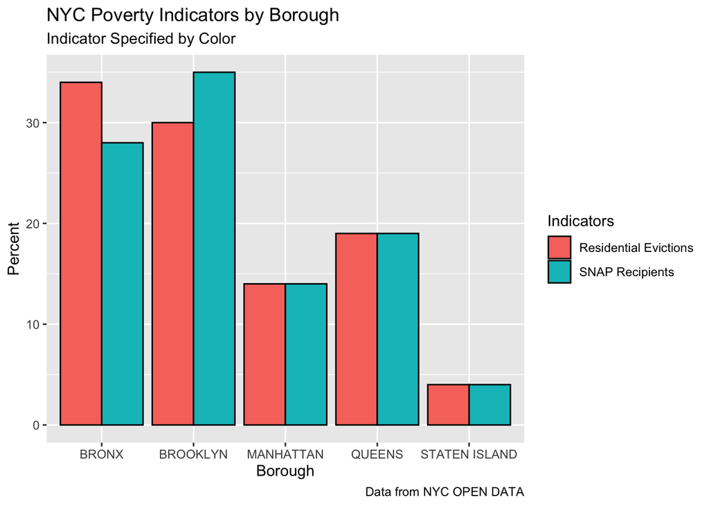

Figure 3

NYC Poverty Indicators

| Borough | Residential Evictions | SNAP Recipients |
| --- | --- | --- |
| BRONX | 23493 | 8806585 |
| BROOKLYN | 20525 | 10976123 |
| MANHATTAN | 9764 | 4391163 |
| QUEENS | 13231 | 5813533 |
| STATEN ISLAND | 2561 | 1228519 |

Figure 4

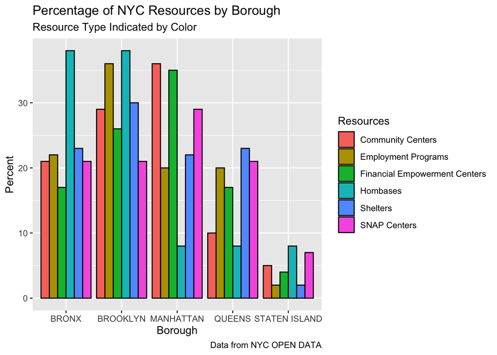

**See below for detailed plots**

Figure 5

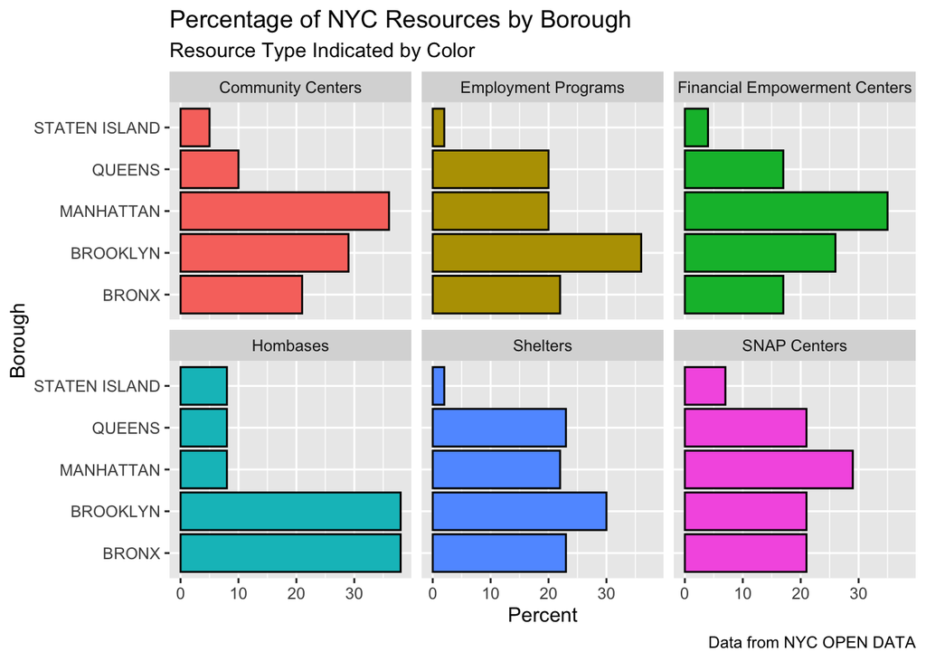

Figure 6

NYC Resources by Borough

| Borough | Hombases | Shelters | Employment Programs | Financial Empowerment Centers | Community Centers | SNAP Centers |
| --- | --- | --- | --- | --- | --- | --- |
| BRONX | 10 | 672 | 45 | 4 | 89 | 3 |
| BROOKLYN | 10 | 897 | 75 | 6 | 125 | 3 |
| MANHATTAN | 2 | 652 | 41 | 8 | 153 | 4 |
| QUEENS | 2 | 673 | 41 | 4 | 42 | 3 |
| STATEN ISLAND | 2 | 63 | 5 | 1 | 21 | 1 |

### Statistics on Resources in New York City

Figure 7

Standard Deviation has been rounded to whole numbers.

Statistics on NYC Resources by Borough

| Resource | Minimum | Maximum | Mean | Standard Deviation | Median | IQR |
| --- | --- | --- | --- | --- | --- | --- |
| Homebase Offices | 2 | 10 | 5.2 | 4 | 2 | 8 |
| Shelters | 63 | 897 | 591.4 | 312 | 672 | 21 |
| Financial Empowerment Centers | 1 | 8 | 4.6 | 3 | 4 | 2 |
| Communities Center | 21 | 153 | 86.0 | 55 | 89 | 83 |
| Employment Programs | 5 | 75 | 41.4 | 25 | 41 | 4 |
| SNAP Centers | 1 | 4 | 2.8 | 1 | 3 | 0 |

## **BRONX**

The Bronx has at least 10,000 more residential evictions than Queens, Manhattan, and Staten Island. Yet, the distribution of shelters and SNAP centers is almost even between Brooklyn, the Bronx, Queens, and Manhattan (see Figure 5). The Bronx and Brooklyn should have significantly more shelters and SNAP Centers compared to Queens and Manhattan.

The Bronx and Brooklyn have the highest percentage of homebases compared to other boroughs. This will serve the Bronx community well because they have the highest amount of residential evictions.

Overall, it is good that most homebases are located in the Bronx and Brooklyn because they can benefit more than other boroughs from that resource. However, there should be more shelters, SNAP centers, financial empowerment centers, employment centers, and community centers, given that they have more people in need to serve.

Figure 8

NYC Resources in the Bronx

| Borough | Hombases | Shelters | Employment Programs | Financial Empowerment Centers | Community Centers | SNAP Centers |
| --- | --- | --- | --- | --- | --- | --- |
| BRONX | 10 | 672 | 45 | 4 | 89 | 3 |

Figure 9

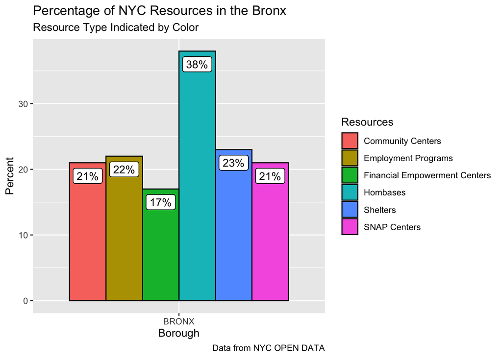

## **BROOKLYN**

As stated in my analysis of the Bronx, the distribution of shelters and SNAP centers is almost even between Brooklyn, the Bronx, Queens, and Manhattan (see Figure 5). However, given the difference in need, as represented by poverty indicators, Brooklyn and the Bronx should have significantly more shelters and SNAP Centers than Queens and Manhattan.

Brooklyn and the Bronx have the highest percentage of homebases compared to other boroughs. This will serve the Brooklyn community well because they have the second highest amount of residential evictions.

Brooklyn has significantly more employment programs than any other borough. This is an excellent example of distributing resources according to need, given that Brooklyn has some of the highest poverty indicators, along with the Bronx.

Overall, it is good that most homebases are located in Brooklyn and the Bronx because they can benefit more than other boroughs from that resource. However, there should be more shelters, SNAP centers, financial empowerment centers, employment centers, and community centers, given that they have more people in need to serve.

Figure 10

NYC Resources in Brooklyn

| Borough | Hombases | Shelters | Employment Programs | Financial Empowerment Centers | Community Centers | SNAP Centers |
| --- | --- | --- | --- | --- | --- | --- |
| BROOKLYN | 10 | 897 | 75 | 6 | 125 | 3 |

Figure 11

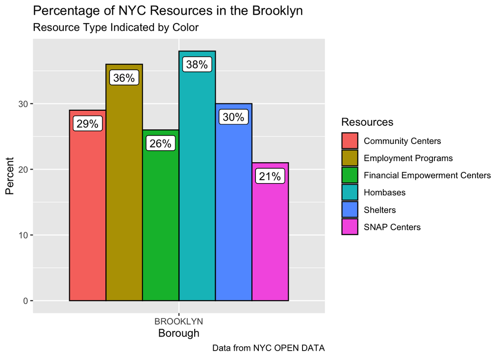

## **MANHATTAN**

Figure 12

NYC Resources in Manhattan

| Borough | Hombases | Shelters | Employment Programs | Financial Empowerment Centers | Community Centers | SNAP Centers |
| --- | --- | --- | --- | --- | --- | --- |
| MANHATTAN | 2 | 652 | 41 | 8 | 153 | 4 |

Figure 13

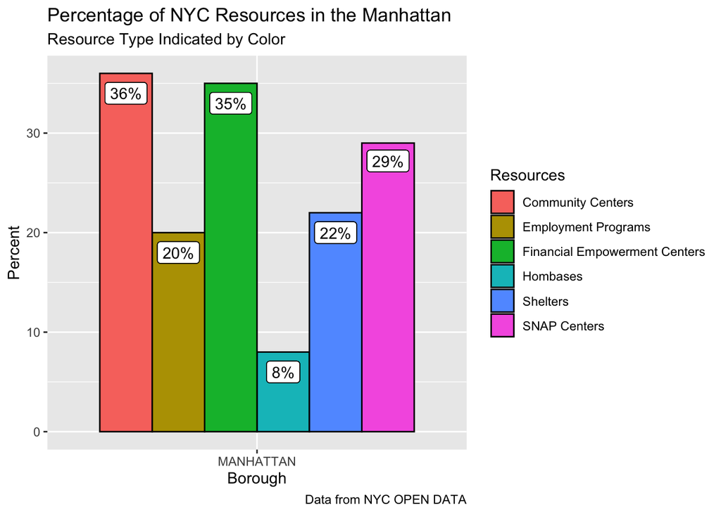

## **QUEENS**

Figure 14

NYC Resources in Queens

| Borough | Hombases | Shelters | Employment Programs | Financial Empowerment Centers | Community Centers | SNAP Centers |
| --- | --- | --- | --- | --- | --- | --- |
| QUEENS | 2 | 673 | 41 | 4 | 42 | 3 |

Figure 15

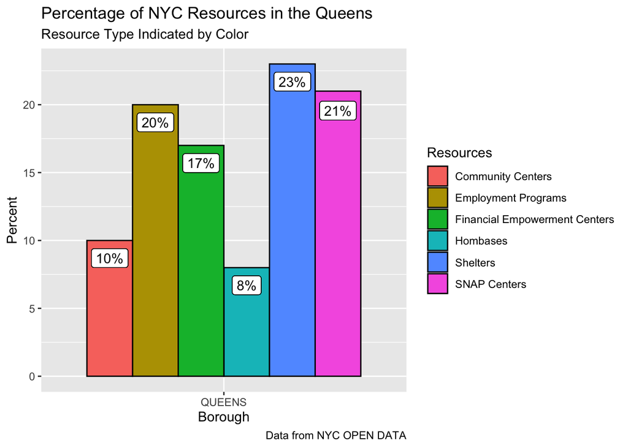

## **STATEN ISLAND**

Figure 16

NYC Resources in Staten Island

| Borough | Hombases | Shelters | Employment Programs | Financial Empowerment Centers | Community Centers | SNAP Centers |
| --- | --- | --- | --- | --- | --- | --- |
| STATEN ISLAND | 2 | 63 | 5 | 1 | 21 | 1 |

Figure 17

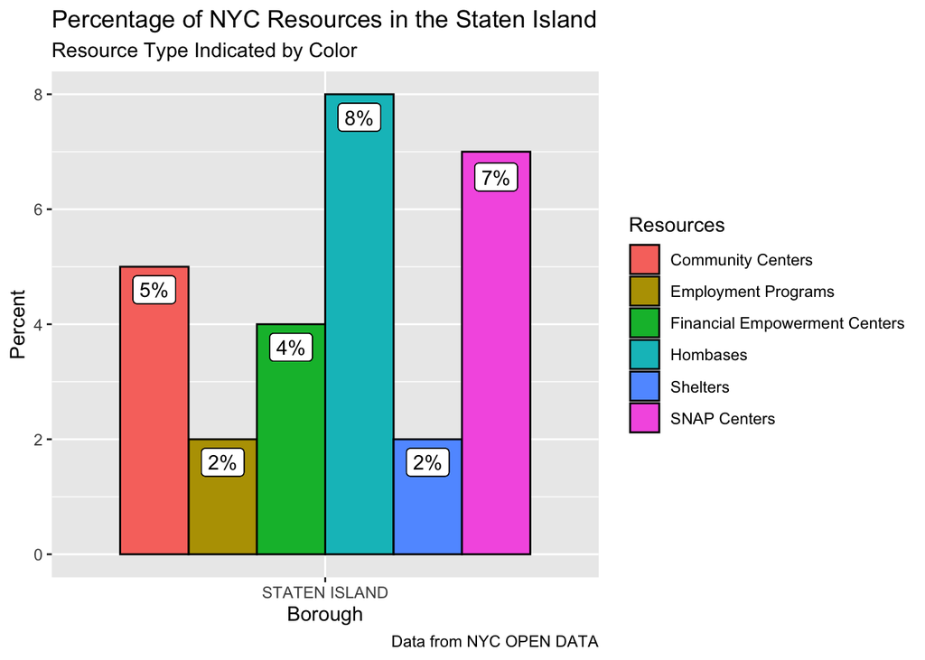

## **CONCLUSION**

The Bronx and Brooklyn have the highest need. However, surprisingly, the graphs do not show a significant increase in resources like they do in the graph on poverty indicators, with homebases being an expectation. Nevertheless, for all the resource distributions, they are at least among the top three boroughs in addition to Manhattan.

The distribution of employment programs, shelters, and SNAP centers has an almost equal percentage across the four boroughs of the Bronx, Brooklyn, Queens, and Manhattan, with somm exceptions (see statistics tab for more analysis on these resources)

Staten Island has the least need by a significant amount, which is clearly reflected in the distribution of resources as they have a tiny proportion of each resource.

## *STATISTICS*

I will use ANOVA tables to confirm the relationships between the boroughs of Bronx, Brooklyn, Queens, and Manhattan and the resources of employment programs, shelters, and SNAP centers that were visualized in the bar graphs in figure 5.

In my conclusion, I stated that these resources appear to be almost equally distributed in the graphs (see figure 5), with some variation, such as one borough being higher. The F Statistics in the ANOVA table demonstrates the strength of a model and provides a number to compare. I will compare the strengths of models made up of one borough (using dummy variables) and one of the above resources.

### Employment programs

```
##  Analysis of Variance Table (Type III SS)
##  Model: borough_bronx ~ employment_programs_count
##
##                             SS df    MS     F    PRE     p
##  ----- --------------- | -----  - ----- ----- ------ -----
##  Model (error reduced) | 0.005  1 0.005 0.020 0.0066 .8969
##  Error (from model)    | 0.795  3 0.265
##  ----- --------------- | -----  - ----- ----- ------ -----
##  Total (empty model)   | 0.800  4 0.200
```

```
##  Analysis of Variance Table (Type III SS)
##  Model: borough_brooklyn ~ employment_programs_count
##
##                             SS df    MS     F    PRE     p
##  ----- --------------- | -----  - ----- ----- ------ -----
##  Model (error reduced) | 0.458  1 0.458 4.009 0.5720 .1390
##  Error (from model)    | 0.342  3 0.114
##  ----- --------------- | -----  - ----- ----- ------ -----
##  Total (empty model)   | 0.800  4 0.200
```

```
##  Analysis of Variance Table (Type III SS)
##  Model: borough_queens ~ employment_programs_count
##
##                             SS df    MS     F    PRE     p
##  ----- --------------- | -----  - ----- ----- ------ -----
##  Model (error reduced) | 0.000  1 0.000 0.000 0.0001 .9885
##  Error (from model)    | 0.800  3 0.267
##  ----- --------------- | -----  - ----- ----- ------ -----
##  Total (empty model)   | 0.800  4 0.200
```

```
##  Analysis of Variance Table (Type III SS)
##  Model: borough_manhattan ~ employment_programs_count
##
##                             SS df    MS     F    PRE     p
##  ----- --------------- | -----  - ----- ----- ------ -----
##  Model (error reduced) | 0.000  1 0.000 0.000 0.0001 .9885
##  Error (from model)    | 0.800  3 0.267
##  ----- --------------- | -----  - ----- ----- ------ -----
##  Total (empty model)   | 0.800  4 0.200
```

### Shelters

```
##  Analysis of Variance Table (Type III SS)
##  Model: borough_bronx ~ shelters_count
##
##                             SS df    MS     F    PRE     p
##  ----- --------------- | -----  - ----- ----- ------ -----
##  Model (error reduced) | 0.017  1 0.017 0.064 0.0209 .8168
##  Error (from model)    | 0.783  3 0.261
##  ----- --------------- | -----  - ----- ----- ------ -----
##  Total (empty model)   | 0.800  4 0.200
```

```
##  Analysis of Variance Table (Type III SS)
##  Model: borough_brooklyn ~ shelters_count
##
##                             SS df    MS     F    PRE     p
##  ----- --------------- | -----  - ----- ----- ------ -----
##  Model (error reduced) | 0.240  1 0.240 1.284 0.2998 .3395
##  Error (from model)    | 0.560  3 0.187
##  ----- --------------- | -----  - ----- ----- ------ -----
##  Total (empty model)   | 0.800  4 0.200
```

```
##  Analysis of Variance Table (Type III SS)
##  Model: borough_queens ~ shelters_count
##
##                             SS df    MS     F    PRE     p
##  ----- --------------- | -----  - ----- ----- ------ -----
##  Model (error reduced) | 0.017  1 0.017 0.066 0.0214 .8145
##  Error (from model)    | 0.783  3 0.261
##  ----- --------------- | -----  - ----- ----- ------ -----
##  Total (empty model)   | 0.800  4 0.200
```

```
##  Analysis of Variance Table (Type III SS)
##  Model: borough_manhattan ~ shelters_count
##
##                             SS df    MS     F    PRE     p
##  ----- --------------- | -----  - ----- ----- ------ -----
##  Model (error reduced) | 0.009  1 0.009 0.036 0.0118 .8620
##  Error (from model)    | 0.791  3 0.264
##  ----- --------------- | -----  - ----- ----- ------ -----
##  Total (empty model)   | 0.800  4 0.200
```

### SNAP centers

```
##  Analysis of Variance Table (Type III SS)
##  Model: borough_bronx ~ snap_centers_count
##
##                             SS df    MS     F    PRE     p
##  ----- --------------- | -----  - ----- ----- ------ -----
##  Model (error reduced) | 0.008  1 0.008 0.032 0.0104 .8703
##  Error (from model)    | 0.792  3 0.264
##  ----- --------------- | -----  - ----- ----- ------ -----
##  Total (empty model)   | 0.800  4 0.200
```

```
##  Analysis of Variance Table (Type III SS)
##  Model: borough_brooklyn ~ snap_centers_count
##
##                             SS df    MS     F    PRE     p
##  ----- --------------- | -----  - ----- ----- ------ -----
##  Model (error reduced) | 0.008  1 0.008 0.032 0.0104 .8703
##  Error (from model)    | 0.792  3 0.264
##  ----- --------------- | -----  - ----- ----- ------ -----
##  Total (empty model)   | 0.800  4 0.200
```

```
##  Analysis of Variance Table (Type III SS)
##  Model: borough_queens ~ snap_centers_count
##
##                             SS df    MS     F    PRE     p
##  ----- --------------- | -----  - ----- ----- ------ -----
##  Model (error reduced) | 0.008  1 0.008 0.032 0.0104 .8703
##  Error (from model)    | 0.792  3 0.264
##  ----- --------------- | -----  - ----- ----- ------ -----
##  Total (empty model)   | 0.800  4 0.200
```

```
##  Analysis of Variance Table (Type III SS)
##  Model: borough_manhattan ~ snap_centers_count
##
##                             SS df    MS     F    PRE     p
##  ----- --------------- | -----  - ----- ----- ------ -----
##  Model (error reduced) | 0.300  1 0.300 1.800 0.3750 .2722
##  Error (from model)    | 0.500  3 0.167
##  ----- --------------- | -----  - ----- ----- ------ -----
##  Total (empty model)   | 0.800  4 0.200
```